# 07-4 Causal Inference

John Fieberg

We will consider a data set from an **randomized experiment** that evaluated the effect of server posture (standing vs. squatting) on the size of tip left by restaurant customers. The study was conducted by a server, who flipped a coin to randomly determine whether they would stand or squat when they first visited a table and introduced themselves to their customers. All subsequent interactions were performed from a standing position. The server also recorded additional information that might influence the size of the the tip.

The data set is contained in the `experimentr` package. The code below will load the data and format some of the variables so that they are easier to understand:

```r
library(experimentr)
library(dplyr)
data(lynn)
tipping <- lynn %>% mutate(Shift = ifelse(daytime==0, "Day", "Evening"),
                        MaleFemale = ifelse(female== 1, "Female", "Male"),
                        Posture = ifelse(crouch==1, "Crouch", "Standing"),
                        Payment = ifelse(paid_by_credit_card==1, "Credit Card", "Cash")) %>%
  rename(Groupsize = groupsize, Tip = tip, Bill = bill)%>%
  select(Groupsize, Bill, Tip, Shift, MaleFemale, Posture, Payment)
```

Now, the `tipping` data set contains the following variables:

- `Groupsize` = number of customers dining at table
- `Bill` = total bill amount in dollars
- `Tip` = tip amount in dollars
- `Shift` = whether the customer or group of customers dined during a Day or Evening shift
- `MaleFemale` = Whether the bill was paid for by a Male or Female customer (note, other gender identifications were unfortunately not included in the experiment)
- `Posture` = whether the server was Crouched or Standing
- `Payment` = whether the bill was paid for using a Credit card or Cash.
1. Create a DAG that represents possible connections between of the different variables in the data set. Remember, these data come from a randomized experiment. That *should* influence the connections between `Posture` and the other explanatory variables in the data set.

```r
library(ggdag)
```

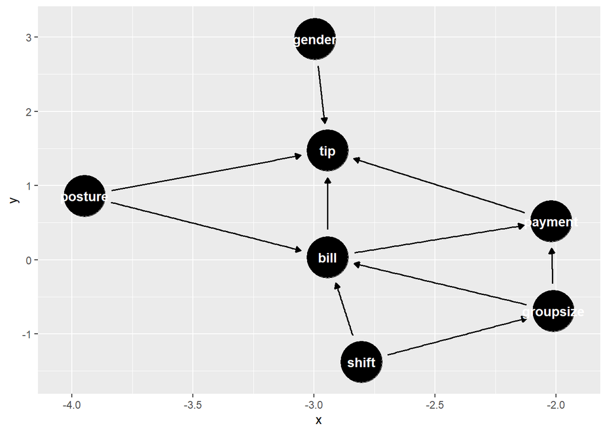

```r
library(ggplot2)
dag_object <- ggdag::dagify(tip~payment+bill+posture+gender,
                            payment~bill+groupsize,
                            bill~groupsize+shift+posture,
                            groupsize~shift)
ggdag::ggdag(dag_object)
```

2. Use linear regression to estimate the **direct effect** of posture on the amount that customers tip.
3. Use linear regression to estimate the **total effect** of posture on the amount that customers tip. (3 pts)

## Compare to other model selection approaches

Let’s look at stepwise backwards selection

```r
MASS::stepAIC(lm(Tip~Groupsize+Bill+Shift+MaleFemale+Posture+Payment, data=tipping))
```

```
## Start:  AIC=-71.36
## Tip ~ Groupsize + Bill + Shift + MaleFemale + Posture + Payment
##
##              Df Sum of Sq     RSS     AIC
## - Groupsize   1     0.048  83.182 -73.275
## - MaleFemale  1     0.142  83.275 -73.109
## - Shift       1     0.291  83.425 -72.843
## <none>                     83.133 -71.361
## - Payment     1     9.174  92.307 -57.869
## - Posture     1    10.553  93.686 -55.674
## - Bill        1    87.998 171.132  33.493
##
## Step:  AIC=-73.28
## Tip ~ Bill + Shift + MaleFemale + Posture + Payment
##
##              Df Sum of Sq     RSS     AIC
## - MaleFemale  1     0.130  83.312 -75.044
## - Shift       1     0.289  83.471 -74.762
## <none>                     83.182 -73.275
## - Payment     1     9.301  92.483 -59.588
## - Posture     1    10.674  93.856 -57.407
## - Bill        1   205.785 288.966 109.027
##
## Step:  AIC=-75.04
## Tip ~ Bill + Shift + Posture + Payment
##
##           Df Sum of Sq     RSS     AIC
## - Shift    1     0.255  83.567 -76.592
## <none>                  83.312 -75.044
## - Payment  1     9.231  92.543 -61.492
## - Posture  1    10.661  93.973 -59.222
## - Bill     1   206.401 289.713 107.408
##
## Step:  AIC=-76.59
## Tip ~ Bill + Posture + Payment
##
##           Df Sum of Sq     RSS     AIC
## <none>                  83.567 -76.592
## - Payment  1     8.999  92.565 -63.456
## - Posture  1    11.112  94.678 -60.116
## - Bill     1   206.177 289.743 105.424
```

```
##
## Call:
## lm(formula = Tip ~ Bill + Posture + Payment, data = tipping)
##
## Coefficients:
##        (Intercept)                Bill     PostureStanding  PaymentCredit Card
##             0.6013              0.1099             -0.5544              0.5372
```

Let’s see if Augmented Backwards selection puts us somewhere differently. For this to work, it appears that we have to create our own dummy variables. This ends up in the same place…

```r
library(abe)
tipping2 <- tipping %>% mutate(Imale = ifelse(MaleFemale=="Male", 0, 1),
                               Ievening = ifelse(Shift=="Evening", 0,1),
                               IStand = ifelse(Posture=="Standing", 0, 1),
                               ICreditC = ifelse(Payment=="Credit Card", 0,1))
fullmod<-lm(Tip~Groupsize+Bill+Ievening+Imale + IStand + ICreditC, data=tipping2,
            x = TRUE, y = TRUE)
abe(fullmod, criterion = "AIC", verbose=TRUE, exp.beta=FALSE, data=tipping)
```

```
##
##
## Model under investigation:
## lm(formula = Tip ~ Groupsize + Bill + Ievening + Imale + IStand +
##     ICreditC, data = tipping2, x = TRUE, y = TRUE)
## Criterion for non-passive variables: Groupsize : -73.2753 , Bill : 33.4926 , Ievening : -72.8432 , Imale : -73.1088 , IStand : -55.6743 , ICreditC : -57.869
##    black list:  Groupsize : -1.914, Imale : -1.7475, Ievening : -1.482
##            Investigating change in b or exp(b) due to omitting variable  Groupsize  ;  Bill : 0.0144, Ievening : 1e-04, Imale : 9e-04, IStand : 7e-04, ICreditC : 0.0026
##
##
## Model under investigation:
## lm(formula = Tip ~ Bill + Ievening + Imale + IStand + ICreditC,
##     data = tipping2, x = TRUE, y = TRUE)
## Criterion for non-passive variables: Bill : 109.0266 , Ievening : -74.7623 , Imale : -75.0436 , IStand : -57.4065 , ICreditC : -59.5875
##    black list:  Imale : -1.7683, Ievening : -1.487
##            Investigating change in b or exp(b) due to omitting variable  Imale  ;  Bill : 7e-04, Ievening : 0.0019, IStand : 1e-04, ICreditC : 8e-04
##
##
## Model under investigation:
## lm(formula = Tip ~ Bill + Ievening + IStand + ICreditC, data = tipping2,
##     x = TRUE, y = TRUE)
## Criterion for non-passive variables: Bill : 107.4083 , Ievening : -76.5922 , IStand : -59.2221 , ICreditC : -61.4919
##    black list:  Ievening : -1.5485
##            Investigating change in b or exp(b) due to omitting variable  Ievening  ;  Bill : 6e-04, IStand : 0.0027, ICreditC : 0.0033
##
##
## Model under investigation:
## lm(formula = Tip ~ Bill + IStand + ICreditC, data = tipping2,
##     x = TRUE, y = TRUE)
## Criterion for non-passive variables: Bill : 105.4239 , IStand : -60.1156 , ICreditC : -63.4563
## black list: empty
##
##
## Final model:
## lm(formula = Tip ~ Bill + IStand + ICreditC, data = tipping2,
##     x = TRUE, y = TRUE)
```

```
##
## Call:
## lm(formula = Tip ~ Bill + IStand + ICreditC, data = tipping2,
##     x = TRUE, y = TRUE)
##
## Coefficients:
## (Intercept)         Bill       IStand     ICreditC
##      0.5842       0.1099       0.5544      -0.5372
```

We could also look at forward stepwise selection using:

```r
min.model <- lm(Tip ~ 1, data=tipping)
step(min.model, scope=( ~ Groupsize+Bill+Shift+MaleFemale+Posture+Payment), direction="forward", data=tipping)
```

```
## Start:  AIC=133.63
## Tip ~ 1
##
##              Df Sum of Sq    RSS     AIC
## + Bill        1   253.497 106.68 -44.455
## + Groupsize   1   161.471 198.70  47.601
## + Payment     1    59.235 300.94 109.035
## + Posture     1    19.009 341.17 127.603
## <none>                    360.17 133.628
## + MaleFemale  1     0.407 359.77 135.460
## + Shift       1     0.141 360.03 135.570
##
## Step:  AIC=-44.46
## Tip ~ Bill
##
##              Df Sum of Sq     RSS     AIC
## + Posture     1   14.1123  92.565 -63.456
## + Payment     1   11.9992  94.678 -60.116
## <none>                    106.678 -44.455
## + Shift       1    0.2236 106.454 -42.766
## + Groupsize   1    0.0982 106.579 -42.592
## + MaleFemale  1    0.0245 106.653 -42.489
##
## Step:  AIC=-63.46
## Tip ~ Bill + Posture
##
##              Df Sum of Sq    RSS     AIC
## + Payment     1    8.9986 83.567 -76.592
## <none>                    92.565 -63.456
## + Groupsize   1    0.1862 92.379 -61.754
## + MaleFemale  1    0.0526 92.513 -61.540
## + Shift       1    0.0223 92.543 -61.492
##
## Step:  AIC=-76.59
## Tip ~ Bill + Posture + Payment
##
##              Df Sum of Sq    RSS     AIC
## <none>                    83.567 -76.592
## + Shift       1  0.254534 83.312 -75.044
## + MaleFemale  1  0.095988 83.471 -74.762
## + Groupsize   1  0.035932 83.531 -74.656
```

```
##
## Call:
## lm(formula = Tip ~ Bill + Posture + Payment, data = tipping)
##
## Coefficients:
##        (Intercept)                Bill     PostureStanding  PaymentCredit Card
##             0.6013              0.1099             -0.5544              0.5372
```

This gets us to the same place.

# Bootstrap Stability

```r
library(rms)
set.seed(130)
fullmod.ols<-ols(Tip~Groupsize+Bill+Shift+MaleFemale+Posture+Payment, data=tipping,
                 x = TRUE, y = TRUE)
validate(fullmod.ols, bw = TRUE)
```

```
##
##      Backwards Step-down - Original Model
##
##  Deleted    Chi-Sq d.f. P      Residual d.f. P      AIC   R2
##  Groupsize  0.08   1    0.7747 0.08     1    0.7747 -1.92 0.769
##  MaleFemale 0.22   1    0.6383 0.30     2    0.8594 -3.70 0.769
##  Shift      0.43   1    0.5112 0.73     3    0.8650 -5.27 0.768
##
## Approximate Estimates after Deleting Factors
##
##                        Coef     S.E. Wald Z         P
## Intercept            0.6013 0.157872  3.809 1.395e-04
## Bill                 0.1099 0.005879 18.700 0.000e+00
## Posture=Standing    -0.5544 0.127705 -4.341 1.417e-05
## Payment=Credit Card  0.5372 0.137512  3.907 9.357e-05
##
## Factors in Final Model
##
## [1] Bill    Posture Payment
```

```
##           index.orig training   test optimism index.corrected  n
## R-square      0.7680   0.7803 0.7477   0.0326          0.7354 40
## MSE           0.5646   0.5420 0.6140  -0.0721          0.6367 40
## g             1.4043   1.4406 1.3940   0.0466          1.3577 40
## Intercept     0.0000   0.0000 0.0600  -0.0600          0.0600 40
## Slope         1.0000   1.0000 0.9798   0.0202          0.9798 40
##
## Factors Retained in Backwards Elimination
##
##  Groupsize Bill Shift MaleFemale Posture Payment
##  *         *                     *       *
##  *         *    *     *          *       *
##            *                     *       *
##            *                     *       *
##  *         *                     *       *
##            *                     *       *
##            *                     *       *
##  *         *                     *       *
##            *                     *       *
##            *                     *
##            *                     *       *
##            *                     *       *
##  *         *    *                *       *
##  *         *    *                *       *
##  *         *    *                *       *
##            *                     *       *
##            *    *     *          *       *
##            *                     *       *
##            *    *                *       *
##  *         *    *     *          *       *
##            *                     *       *
##            *                     *       *
##  *         *    *                *       *
##            *                     *       *
##            *                     *       *
##            *    *                *       *
##            *                     *       *
##            *                     *       *
##            *                     *       *
##            *                     *
##            *                     *       *
##            *                     *
##            *                     *       *
##            *                     *       *
##  *         *    *     *          *       *
##            *                     *       *
##            *                     *       *
##            *                     *       *
##            *                     *       *
##            *                     *       *
##
## Frequencies of Numbers of Factors Retained
##
##  2  3  4  5  6
##  3 24  5  5  3
```